# Award Prediction

Christian

2023-03-05

# Award Prediction

For this project we’ll be using data scraped from the Wikipedia lists of winners for each award:

- Oscars
- Golden Globes
- Palme D’Or
- BAFTAs

## Import Data

### Oscar Data

Firstly, we need to import the data on Oscar winners. This dataset contains data on the name of the film, year nominated, awards won, awards nominated, and whether that film won best picture.

```r
oscar_data <- read_csv("Data/oscar_best_film.csv")

head(oscar_data)
```

```
## # A tibble: 6 x 5
##   Film                    Year Awards Nominations Won
##   <chr>                  <dbl>  <dbl>       <dbl> <lgl>
## 1 CODA                    2021      3           3 TRUE
## 2 Dune                    2021      6          10 FALSE
## 3 The Eyes of Tammy Faye  2021      2           2 FALSE
## 4 No Time to Die          2021      1           3 FALSE
## 5 The Windshield Wiper    2021      1           1 FALSE
## 6 The Long Goodbye        2021      1           1 FALSE
```

### Golden Globes Data

Next, we’ll need to import the data on Golden Globes. The data requires a little bit of cleaning before we can use it. Specifically we’ll need to extract the names of the film that won, or associated with the winner of, each award.

```r
gg_data <- read_csv("Data/gg_winners.csv") %>%
  mutate(Year = as.numeric(str_sub(Year, 1, 4)),
         Drama_actor = sapply(str_split(`Drama Actor`, ","), `[`, 2),
         Drama_actress = sapply(str_split(`Drama Actress`, ","), `[`, 2),
         Director = sapply(str_split(Director, ","), `[`, 2),
         MC_actor = sapply(str_split(`Musical/Comedy Actor`, ","), `[`, 2),
         MC_actress = sapply(str_split(`Musical/Comedy Actress`, ","), `[`, 2)) %>%
  select(Year,
         Drama_actor,
         Drama_actress,
         Director,
         MC_actor,
         MC_actress)
head(gg_data)
```

```
## # A tibble: 6 x 6
##    Year Drama_actor         Drama_actress    Director                   MC_actor                    MC_actress
##   <dbl> <chr>               <chr>            <chr>                      <chr>                       <chr>
## 1  1951 Death of a Salesman The Blue Veil    Death of a Salesman        On the Riviera              Too Young to Kiss
## 2  1952 High Noon           Come Back        The Greatest Show on Earth Singin' in the Rain         With a Song in My Heart
## 3  1953 The Actress         Roman Holiday    From Here to Eternity      The Moon Is Blue            Call Me Madam
## 4  1954 On the Waterfront   The Country Girl On the Waterfront          A Star Is Born              A Star Is Born
## 5  1955 Marty               The Rose Tattoo  Picnic                     The Seven Year Itch         Guys and Dolls
## 6  1956 Lust for Life       Anastasia        Baby Doll                  Around the World in 80 Days The King and I
```

### Palme D’Or Winners

After that, we’ll need to import the dataset of Palme D’Or winners. This doesn’t require any cleaning really, just selecting the only relevant columns.

```r
pdo_data <- read_csv("Data/pdo_winners.csv") %>%
  select(Year, Film)
```

### Bafta Data

Finally we’ll need to import the data for the BAFTAS. This will require a bit of cleaning and concatenation of the datasets for each decade.

```r
baftas_list <- list.files("Data/BAFTA")

for (data in baftas_list) {
  data <- read_csv(paste0("Data/BAFTA/", data))
  if (exists("bafta_data")) {
    bafta_data <- rbind(bafta_data, data)
  } else {
    bafta_data <- data
  }
}

bafta_data <- bafta_data %>%
  mutate(Year = as.numeric(substring(Year, 1, 4)),
         Film = gsub('[0-9]{2}', '', Film)) %>%
  select(Year, Film, Won) %>%
  arrange(-Year)

bafta_data$Film[16] <- "1917"

head(bafta_data)
```

```
## # A tibble: 6 x 3
##    Year Film                              Won
##   <dbl> <chr>                             <lgl>
## 1  2022 All Quiet on the Western Front    TRUE
## 2  2022 The Banshees of Inisherin         FALSE
## 3  2022 Elvis                             FALSE
## 4  2022 Everything Everywhere All at Once FALSE
## 5  2022 Tár                               FALSE
## 6  2021 The Power of the Dog              TRUE
```

## Clean Data

Now that we’ve imported the data, we can now begin to construct the dataset for our question.

```r
final_data <- oscar_data %>%

  # join on golden globe data
  left_join(gg_data, by = "Year") %>%
  mutate(gg_drama_actor = ifelse(Film == Drama_actor, TRUE, FALSE),
         gg_drama_actress = ifelse(Film == Drama_actress, TRUE, FALSE),
         gg_director = ifelse(Film == Director, TRUE, FALSE),
         gg_mc_actor = ifelse(Film == MC_actor, TRUE, FALSE),
         gg_mc_actress = ifelse(Film == MC_actress, TRUE, FALSE)) %>%
  select(-Drama_actor,
         -Drama_actress,
         -Director,
         -MC_actor,
         -MC_actress) %>%

  # join on Palme D'Or data
  left_join(pdo_data, by = "Year", suffix = c("", "_pdo")) %>%
  mutate(pdo_winner = ifelse(Film == Film_pdo, TRUE, FALSE)) %>%
  select(-Film_pdo) %>%

  # join the bafta data
  left_join(bafta_data, by = c("Year", "Film"), suffix = c("", "_bafta")) %>%
  mutate(bafta_nominated = ifelse(!is.na(Won_bafta) & !Won_bafta, TRUE, FALSE),
         bafta_winner = ifelse(!is.na(Won_bafta) & Won_bafta, TRUE, FALSE),
         bafta_not_nominated = ifelse(is.na(Won_bafta), TRUE, FALSE)) %>%
  select(-Won_bafta) %>%
  filter(Year >= 1970) %>%
  replace(is.na(.), FALSE)
```

## Perform analysis

```r
index <- createDataPartition(final_data$Won, p = .70, list = FALSE)
train <- final_data[index, ]
test <- final_data[-index, ]


# create binary logiistic model
model <- glm(Won ~ Nominations +
                    gg_drama_actor +
                    gg_drama_actress +
                    gg_director +
                    gg_mc_actor +
                    gg_mc_actress +
                    pdo_winner +
                    bafta_nominated +
                    bafta_winner +
                    bafta_not_nominated,
              family = binomial(),
              data = train)

summary(model)
```

```
##
## Call:
## glm(formula = Won ~ Nominations + gg_drama_actor + gg_drama_actress +
##     gg_director + gg_mc_actor + gg_mc_actress + pdo_winner +
##     bafta_nominated + bafta_winner + bafta_not_nominated, family = binomial(),
##     data = train)
##
## Deviance Residuals:
##      Min        1Q    Median        3Q       Max
## -2.03021  -0.22784  -0.10959  -0.08531   3.03972
##
## Coefficients: (1 not defined because of singularities)
##                         Estimate Std. Error z value Pr(>|z|)
## (Intercept)             -6.11639    0.65636  -9.319  < 2e-16 ***
## Nominations              0.50212    0.08738   5.746 9.12e-09 ***
## gg_drama_actorTRUE      -0.76709    0.70564  -1.087   0.2770
## gg_drama_actressTRUE     0.72415    0.61715   1.173   0.2406
## gg_directorTRUE          0.95683    0.47561   2.012   0.0442 *
## gg_mc_actorTRUE         -0.03288    0.87012  -0.038   0.9699
## gg_mc_actressTRUE       -1.03685    0.92467  -1.121   0.2622
## pdo_winnerTRUE           0.03798    1.20881   0.031   0.9749
## bafta_nominatedTRUE      0.42169    0.50929   0.828   0.4077
## bafta_winnerTRUE         1.05881    0.55956   1.892   0.0585 .
## bafta_not_nominatedTRUE       NA         NA      NA       NA
## ---
## Signif. codes:  0 '***' 0.001 '**' 0.01 '*' 0.05 '.' 0.1 ' ' 1
##
## (Dispersion parameter for binomial family taken to be 1)
##
##     Null deviance: 300.96  on 576  degrees of freedom
## Residual deviance: 170.61  on 567  degrees of freedom
## AIC: 190.61
##
## Number of Fisher Scoring iterations: 7
```

## Evaluate the model

### Confusion matrix

```r
pred_prob <- predict(model, test, type = "response")

test$predicted_winner <- ifelse(pred_prob >= 0.5, "Won", "Didn't Win")

confusion_matrix <- table(ifelse(test$Won == TRUE, "Won", "Didn't Win"), test$predicted_winner)
confusion_matrix
```

```
##
##              Didn't Win Won
##   Didn't Win        222   6
##   Won                14   3
```

### Model accuracy

```r
Accuracy <- sum(diag(confusion_matrix)) / sum(confusion_matrix) * 100
Accuracy
```

```
## [1] 91.83673
```

### Precision

```r
Precision <- (confusion_matrix[2, 2] / sum(confusion_matrix[, 2])) * 100
Precision
```

```
## [1] 33.33333
```

```r
Recall <- (confusion_matrix[2, 2] / sum(confusion_matrix[, 2])) * 100
Recall
```

```
## [1] 33.33333
```

### F1 score

```r
F_Score <- (2 * Precision * Recall / (Precision + Recall)) / 100
F_Score
```

```
## [1] 0.3333333
```

## Plotting ROC curve

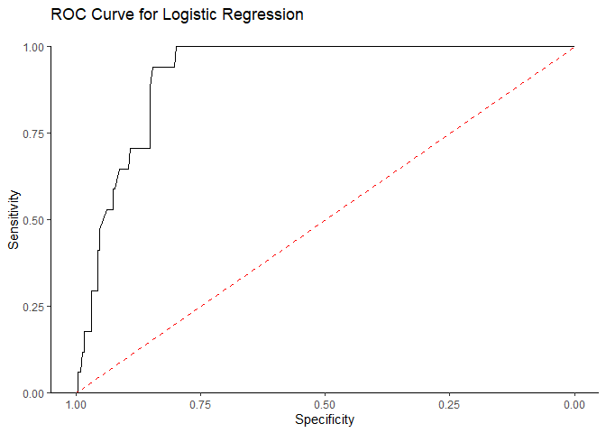

```r
predicted <- predict(model, test, type="response")
rocobj <- roc(test$Won, predicted)

ggroc(rocobj) +
  scale_y_continuous(expand = c(0,0)) +
  geom_abline(slope = 1, intercept = 1, color = "red", linetype = 2) +
  labs(x = "Specificity",
       y = "Sensitivity",
       title = "ROC Curve for Logistic Regression\n") +
  theme_classic()
```

## Create prediction data

```r
# create data for upcoming ceremony
final_pred_data <- read_csv("Data/oscar_best_film_2022.csv") %>%

  # join on golden globe data
  left_join(gg_data, by = "Year") %>%
  mutate(gg_drama_actor = ifelse(Film == Drama_actor, TRUE, FALSE),
         gg_drama_actress = ifelse(Film == Drama_actress, TRUE, FALSE),
         gg_director = ifelse(Film == Director, TRUE, FALSE),
         gg_mc_actor = ifelse(Film == MC_actor, TRUE, FALSE),
         gg_mc_actress = ifelse(Film == MC_actress, TRUE, FALSE)) %>%
  select(-Drama_actor,
         -Drama_actress,
         -Director,
         -MC_actor,
         -MC_actress) %>%

  # join on Palme D'Or data
  left_join(pdo_data, by = "Year", suffix = c("", "_pdo")) %>%
  mutate(pdo_winner = ifelse(Film == Film_pdo, TRUE, FALSE)) %>%
  select(-Film_pdo) %>%

  # join the bafta data
  left_join(bafta_data, by = c("Year", "Film"), suffix = c("", "_bafta")) %>%
  mutate(bafta_nominated = ifelse(!is.na(Won_bafta) & !Won_bafta, TRUE, FALSE),
         bafta_winner = ifelse(!is.na(Won_bafta) & Won_bafta, TRUE, FALSE),
         bafta_not_nominated = ifelse(is.na(Won_bafta), TRUE, FALSE)) %>%
  select(-Won_bafta)


# predict winner for final data
final_pred_data <- final_pred_data %>%
  mutate(Won = predict(model, ., type = "response")) %>%
  arrange(-Won) %>%
  select(Film, Won)

head(final_pred_data)
```

```
## # A tibble: 6 x 2
##   Film                                 Won
##   <chr>                              <dbl>
## 1 All Quiet on the Western Front    0.369
## 2 The Fabelmans                     0.162
## 3 Everything Everywhere All at Once 0.153
## 4 The Banshees of Inisherin         0.153
## 5 Tár                               0.124
## 6 Elvis                             0.0798
```